# STAT 223 Homework 2

Group 5 (Yiluan Song, Peter Trubey)

2/6/2020

## Chapter 2 Problem 19

Solve the characteristic polynomial
$$\Phi(u)=1-\phi_1u-\phi_2u^2=1-0.9u+0.9u^2=0$$

```
## [1] "Roots:"
```

```
##            roots  modulus argument
## 1 0.5+0.9279607i 1.054093  1.07658
## 2 0.5-0.9279607i 1.054093 -1.07658
```

```
## [1] "Reciprocal roots:"
```

[output not shown]

As the modulus of characheristic roots are greater than 1 (modulus of characheristic reciprocal roots smaller than 1), the process is stable.

A general solution to the MA coefficients after inversion are
$$\psi_j=\alpha_1^jp_1(j)+...+\alpha_r^jp_r(j)$$
, where $p_i(j)$ is a polynomial of dergee $m_i-1$.

We get the following $a$ and $b$:

```
##     coefficient   modulus  argument
## 1 0.5+0.269408i 0.5679618  0.494216
## 2 0.5-0.269408i 0.5679618 -0.494216
```

$$\psi_j=\alpha_1^ja+\alpha_2^jb=(0.45-0.8351647i)^j(0.5+0.269408i )+(0.45+0.8351647i)^j(0.5-0.269408i)$$
Visualizing some $\psi$.

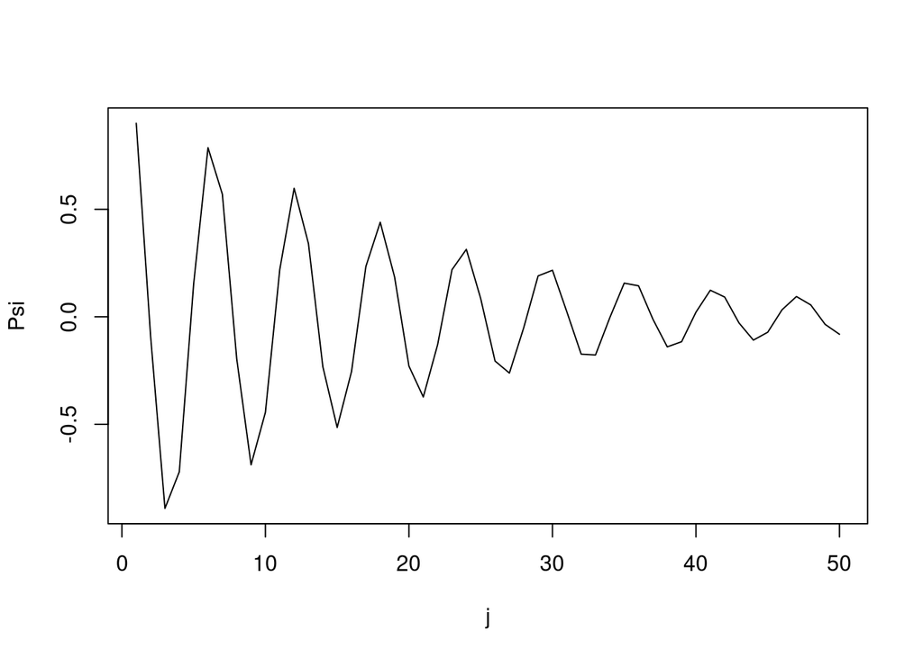

## Chapter 2 Problem 24 (a)

Raw data was first detrended using LOESS regression.

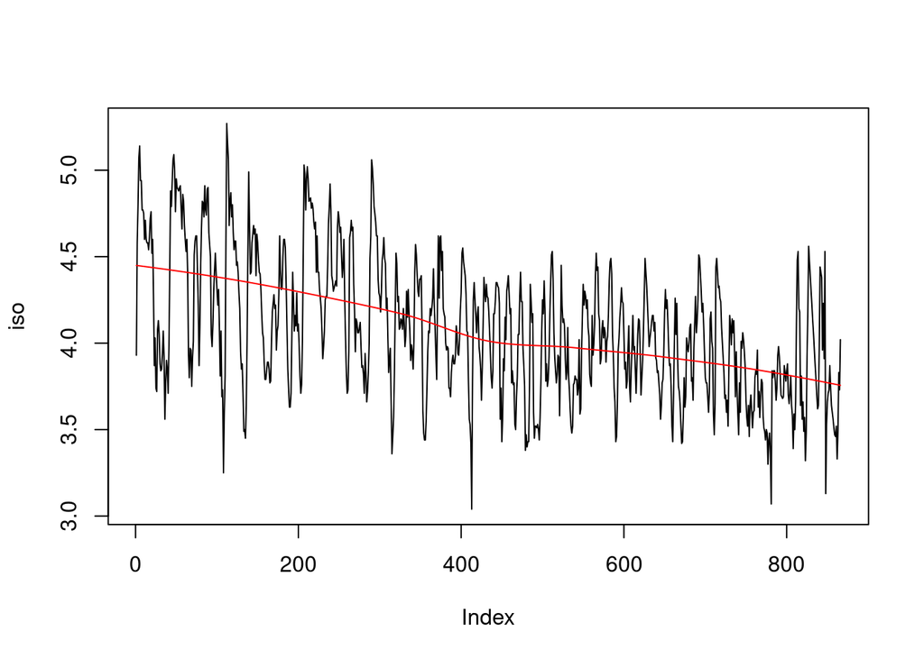

```
## Call:
## loess(formula = iso ~ c(1:n))
##
## Number of Observations: 866
## Equivalent Number of Parameters: 4.35
## Residual Standard Error: 0.3376
```

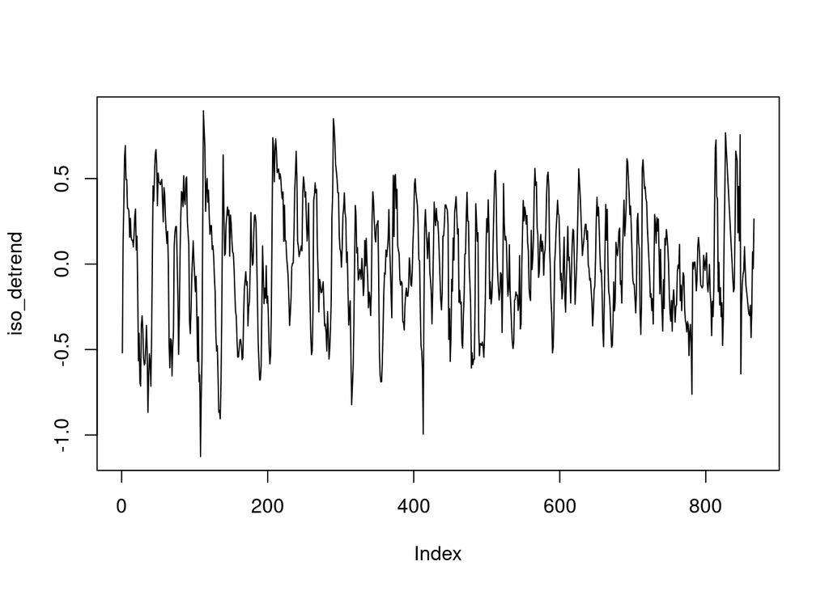

AR Model: $y_t=\sum_{j=1}^{p}\phi_j y_{t-j}+\epsilon_t$, where $\epsilon_t\sim N(0, v)$

I consider this in the form of a linear model $\mathbf{y}=\mathbf{F}'\mathbf{\beta}+\mathbf{\epsilon}$, where $\mathbf{\epsilon}\sim N(\mathbf{0}, v\mathbf{I})$ and computed the MLE of $\beta$ and $v$ as
$$\hat{\mathbf{\beta}}=(\mathbf{F}'\mathbf{F})^{-1}\mathbf{F}\mathbf{y}\text{ (1)}$$
and
$$\hat{v}=s^2=\frac{(\mathbf{y}-\mathbf{F}'\mathbf{\beta})'(\mathbf{y}-\mathbf{F}'\mathbf{\beta})}{T-p}\text{ (2)}$$
, where $T$ is the total number of observations and $p$ is the number of parameters.

I fitted AR(1) to AR(15) models and calculated the AIC and BIC scores using the corresponsing $s^2$ following:
$$AIC=2p+(T-p)\log(s^2_p)$$
$$BIC=\log(T-p)p+(T-p)\log(s^2_p)$$

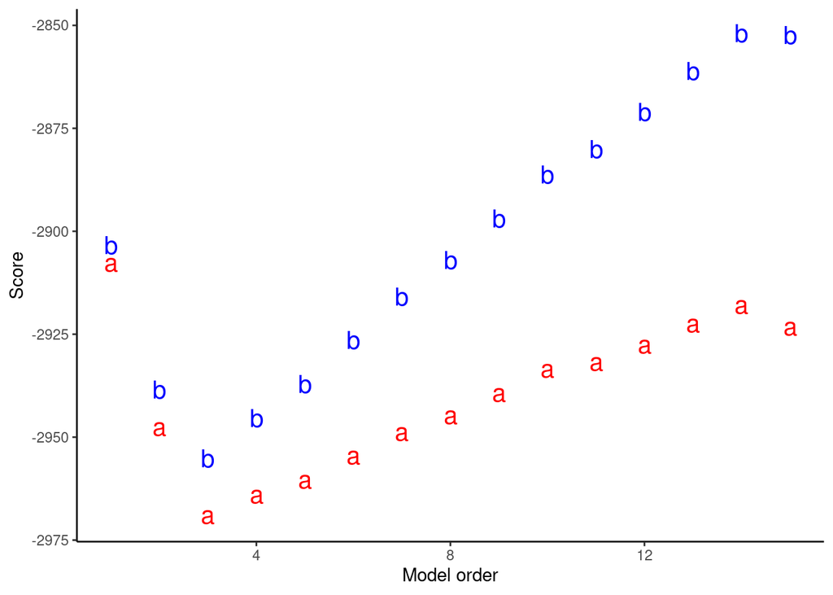

Both AIC and BIC were the lowest at model order 3. The rest of this problem will follow AR(3).

## Chapter 2 Problem 24 (b)

Using eqn 1, the three AR coefficients were estimated as follows.

```
## [1]  0.96664077 -0.02376561 -0.17608165
```

The residuals were calculated using eqn. 2.

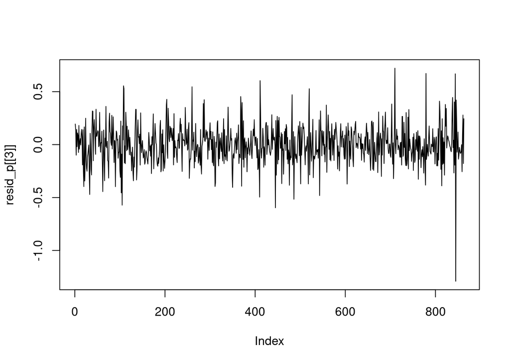

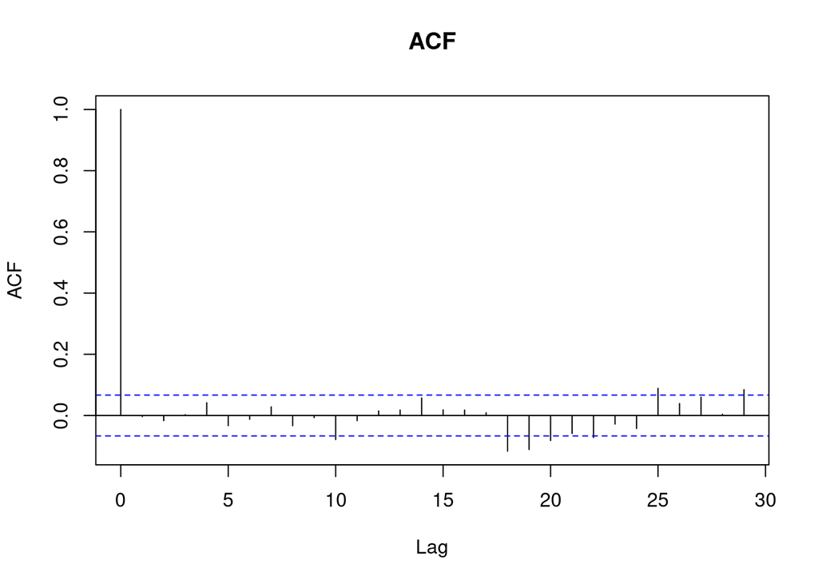

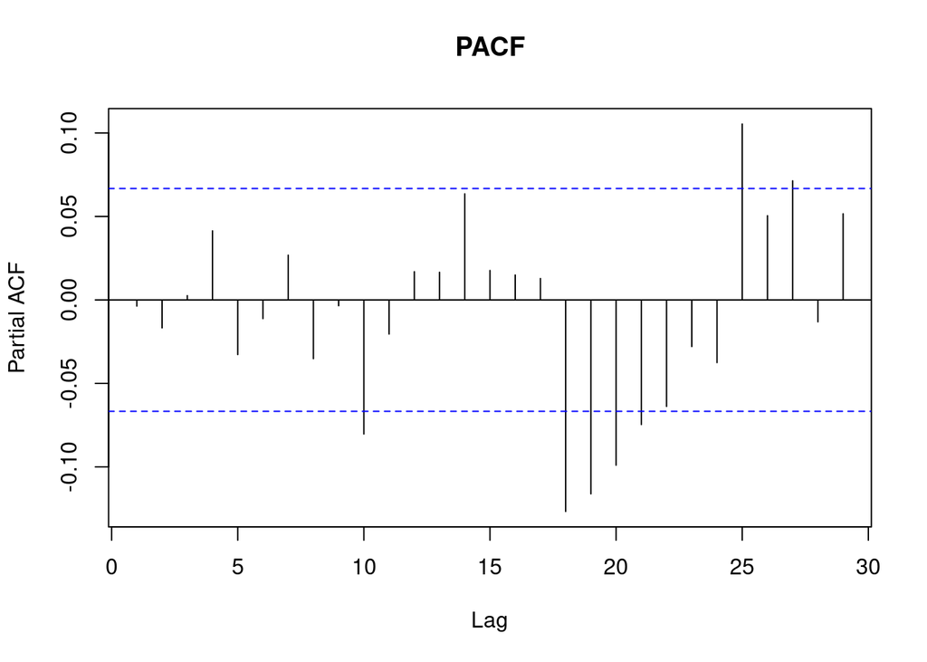

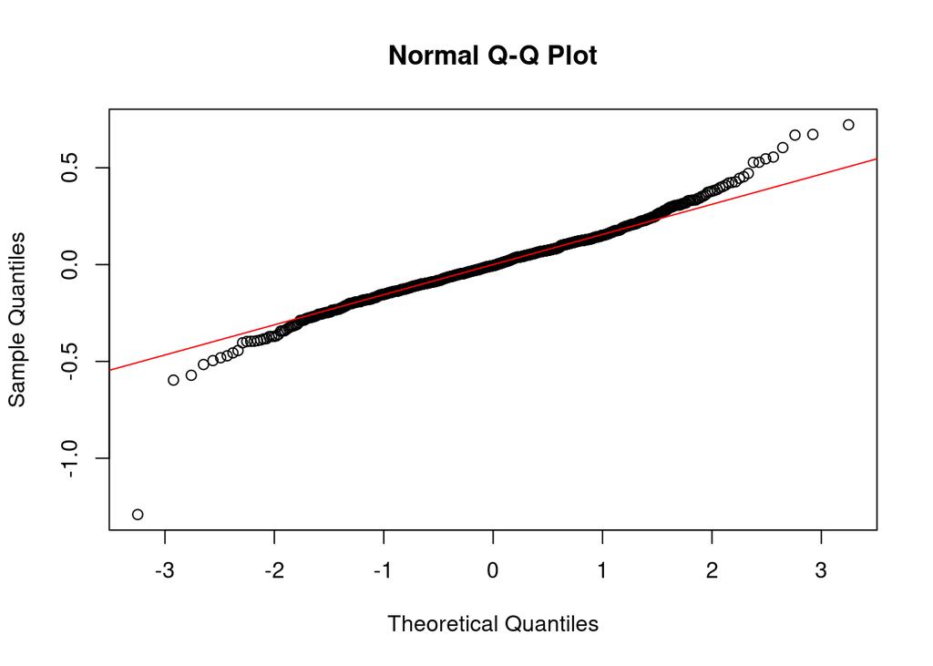

The residuals do not completely satisfy the assumption of normality.

## Chapter 2 Problem 24 (c)

Solving for the characteristic polynomial
$$\Phi(u)=1-\phi_1u-\phi_2u^2-\phi_3u^3=0$$
using the the AR coefficients found in (b), we get the following reciprocal roots:

```
##                 invroot   modulus  argument wavelength
## 1  0.6613180-0.2393247i 0.7032907 0.3472282   18.09526
## 2  0.6613180+0.2393247i 0.7032907 0.3472282   18.09526
## 3 -0.3559953-0.0000000i 0.3559953 3.1415927    2.00000
```

There is one pair of complex reciprocal roots with a modulus of 0.7033 and wavelength of 18.10.

## Chapter 2 Problem 24 (d)

### Method 1: Yule-Walker equations

The h-step-ahead prediction and corresponding MSE based on $y_{1:t}$ are

$$y^{t}_{t+h}=\phi^{(h)}(t, 1)y_t+...+\phi^{(h)}(t, t)y_1=(\phi^{(h)}(t, 1), ..., \phi^{(h)}(t, t))'(y_t, ..., y_1)=\mathbf{\phi}_t^{(h)}y_{t:1} \text{ (3)}$$
and

$$MSE^t_{t+h}=\gamma_0-\mathbf{\gamma'}_t^{(h)}\Gamma_t^{-1}\mathbf{\gamma}_t^{(h)} \text{ (4)}$$

with $\mathbf{\phi}_t^{(h)}$ being the solution of
$$\mathbf{\Gamma}_t\mathbf{\phi}_t^{(h)}=\mathbf{\gamma}_t^{(h)}$$

, where

$$\mathbf{\gamma}_t^{(h)}=(\gamma(h), \gamma(h+1), ..., \gamma(t+h+1))'$$
and
$$\mathbf{\Gamma}_t=\mathbf{\Gamma}_t(1)=\{\gamma(j-h)\}^t_{j, h=1}=\left[
\begin{matrix}
\gamma(0) & \gamma(1) & ... & \gamma(t-1)\\
\gamma(1) & \gamma(0) & ... & \gamma(t-2) \\
\vdots & \vdots & \ddots& \vdots \\
\gamma(t-1) & \gamma(t-2) & ... & \gamma(0)
\end{matrix}
\right]$$

These are equations (2.15) and (2.16) from Prado & West (2010).

First, calculate $\mathbf{\Gamma}_t$ using theoretical autocovariance function. I used the R package *tacvfARMA*.

```
##  num [1:866, 1:866] 0.1128 0.0942 0.0718 0.0473 0.0274 ...
```

Then calculate $\mathbf{\gamma}_t^{(h)}$ for $h$ from 1 to 100.

```
##  num [1:866, 1:100] 0.0942 0.0718 0.0473 0.0274 0.0127 ...
```

Solve for $\mathbf{\phi}_t^{(h)}$ for $h$ from 1 to 100.

```
##  num [1:866, 1:100] 9.67e-01 -2.38e-02 -1.76e-01 2.14e-16 -7.69e-17 ...
```

A sanity check: For stationary AR(3) model, $\phi(3, 1), \phi(3, 2), \phi(3, 3)$ should correspond to the AR coefficients $\phi_1,\phi_2,\phi_3$ and decays to 0 after 3.

Recall the AR coefficients are:

```
## [1]  0.96664 -0.02377 -0.17608
```

When h=1, the first 10 PACF we have are:

```
##  [1]  0.96664 -0.02377 -0.17608  0.00000  0.00000  0.00000  0.00000  0.00000
##  [9]  0.00000  0.00000
```

We can now calculate $y^{t}_{t+h}$ where $h=1:100$ using eqn. 3:

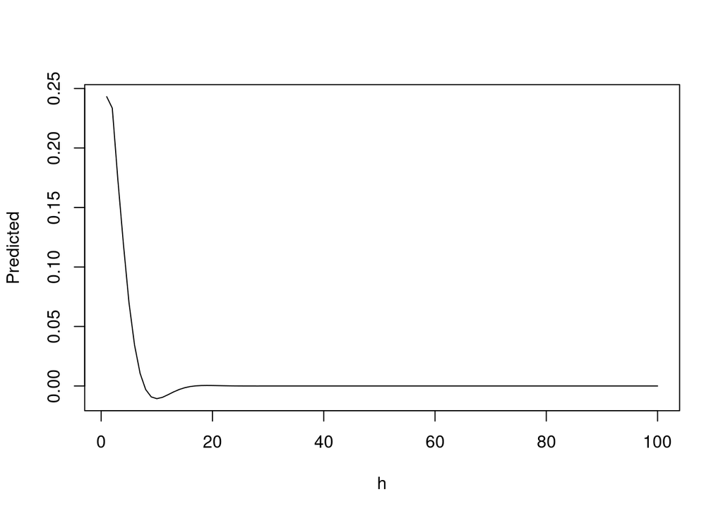

Calculate $MSE^{t}_{t+h}$ where $h=1:100$ using eqn. 4:

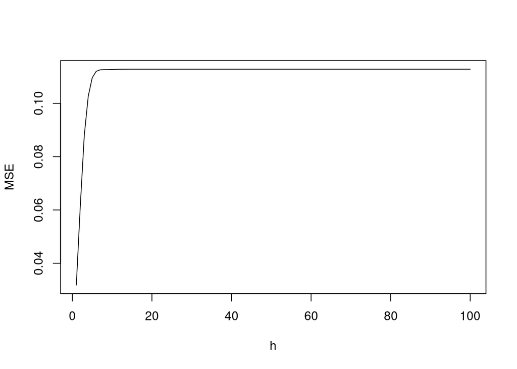

Visualize these predictions with 95% prediction intervals. Here the 95% prediction intervals were calculated as $(y^{t}_{t+h}-1.96\sqrt {MSE^{t}_{t+h}}, y^{t}_{t+h}+1.96 \sqrt{MSE^{t}_{t+h}})$.

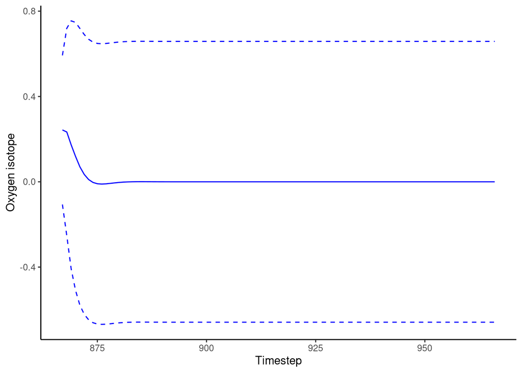

Visualize predicted values together with previously observed values.

[figure not shown]

### Method 2: Innovations algorithm (Brockwell and Davis, 1991)

Alternatively, we can calculate the $y^{t}_{t+h}$ and $MSE^{t}_{t+h}$ recursively, using the following equations.
$$y^{t}_{t+h}=\sum_{j=h}^{t+h-1}b_{t+h-1, j}(y_{t+h-j}-y_{t+h-j}^{t+h-j-1})\text{ (5)}$$
and
$$MSE^{t}_{t+h}=\gamma(0)-\sum_{j=h}^{t+h-1}b_{t+h-1, j}^2 MSE_{t+h-j}^{t+h-j-1}\text{ (6)}$$
, for $t\ge1$ where, for $j=0:(t-1)$
$$b_{t+h-1,t+h-1-j}=\frac{\gamma(t+h-1-j)-\sum_{l=0}^{j-1}b_{j, j-l} b_{t+h-1, t+h-1-l} MSE^l_{l+1}} {MSE^j_{j+1}}$$
The algorithm is initialized at $y^0_1=0$ and $MSE^0_1=\gamma(0)$.

These are equations (2.19) and (2.20) from Prado & West (2010).

The general workflow of this code is to 1) update all $b$, starting from $b_{t+h-1,t+h-1}$, ending at $b_{t+h-1,h}$; 2) update all $y^t_{t+h}$ using eqn. 5; 3) update all $MSE^{t}_{t+h}$ using eqn. 6.

The calculation of $b$ was fairly slow, so I used parallel computing and stored the output into a csv file. Note that calculations for $h=1$ needs to be done first before calculating for other $h$ in parallel. The code for innovations algorithm is included in this R markdown file.

The results from this method are exactly the same as those from method 1. Here I show the first 10 sets of output.

```
##    y_pred_Method_1 MSE_pred_Method_1 y_pred_Method_2 MSE_pred_Method_2
## 1       0.24310113        0.03181378      0.24310113        0.03181378
## 2       0.23347253        0.06154041      0.23347253        0.06154041
## 3       0.17342959        0.08792182      0.17342959        0.08792182
## 4       0.11928984        0.10268433      0.11928984        0.10268433
## 5       0.07007854        0.10961136      0.07007854        0.10961136
## 6       0.03436801        0.11200893      0.03436801        0.11200893
## 7       0.01055130        0.11258299      0.01055130        0.11258299
## 8      -0.00295700        0.11263689     -0.00295700        0.11263689
## 9      -0.00916069        0.11264127     -0.00916069        0.11264127
## 10     -0.01064271        0.11268247     -0.01064271        0.11268247
```